# Model evaluation

Ich

3/9/2019

```r
knitr::opts_chunk$set(
  comment = "#>",
  collapse = TRUE,
  message = FALSE,
  warning = FALSE,
  cache = TRUE,
  out.width = "70%",
  fig.align = 'center',
  fig.width = 6,
  fig.asp =  0.618,  # 1 / phi
  fig.show = "hold",
  size = "tiny"
)
```

# Load packages

```r
library(sjmisc)
library(viridis)
library(pradadata)  # elec data
library(tidyverse)
library(knitr)
library(tidylog)
library(gghighlight)



library(rethinking)  # Bayes modeling
library("rstanarm")
```

# Data

## Load data

```r
load("../objects/models.Rda")

d79 <- read.csv("../objects/d79.csv")
d <- read_csv("../objects/d_prepared.csv")
```

# Change options

```
theme_set(theme_classic())

options(ggplot2.continuous.colour="viridis")
options(ggplot2.continuous.fill = "viridis")

scale_colour_discrete <- scale_colour_viridis_d
scale_fill_discrete <- scale_fill_viridis_d
```

## Check model object

```r
names(models)
```

```
#> [1] "m0"  "m0a" "m0b" "m1b" "m2"  "m2b" "m3b" "m4b"
```

# Model comparison

## Compare null models:

```r
compare_null_models <- compare( models[["m0a"]], models[["m0b"]])
compare_null_models
```

```
#>                  WAIC pWAIC dWAIC weight    SE  dSE
#> models[["m0a"]] 209.4   2.4   0.0   0.51 16.33   NA
#> models[["m0b"]] 209.5   2.5   0.1   0.49 16.39 0.13
```

## Compare models of reduced sample size

### Define model vector

Here are only the Cauchy models:

```r
models79 <- models[c("m0b",
                     "m1b",
                     "m2b",
                     "m3b",
                     "m4b")]

length(models79)
```

```
#> [1] 5
```

```r
names(models79)
```

```
#> [1] "m0b" "m1b" "m2b" "m3b" "m4b"
```

```r
names(models)
```

```
#> [1] "m0"  "m0a" "m0b" "m1b" "m2"  "m2b" "m3b" "m4b"
```

```r
model_names <- names(models79)
```

### Compare the models

Only models with Cauchy Sigmas:

```r
compare_reduced_sample <- compare(models[["m0b"]],
                                  models[["m1b"]],
                                  models[["m2b"]],
                                  models[["m3b"]],
                                  models[["m4b"]])
compare_reduced_sample
```

```
#>                  WAIC pWAIC dWAIC weight    SE   dSE
#> models[["m4b"]] 106.0  12.8   0.0      1 11.32    NA
#> models[["m1b"]] 144.5   7.4  38.4      0 12.13 13.00
#> models[["m3b"]] 153.8   4.8  47.8      0 12.50 12.97
#> models[["m2b"]] 209.3   4.7 103.3      0 13.54 13.85
#> models[["m0b"]] 209.5   2.5 103.5      0 16.39 16.67
```

# Best model

## Get best model

Which model ist best? Let’s define the model with the lowest WAIC as best:

```r
compare_reduced_sample@output %>%
  rownames_to_column(var = "model_name") %>%
  slice(which.min(WAIC)) -> best_model

best_model
```

```
#>        model_name     WAIC    pWAIC dWAIC weight       SE dSE
#> 1 models[["m4b"]] 106.0426 12.77713     0      1 11.32059  NA
```

And now extract the *name* of the best model:

```r
best_model_name <-
  best_model %>%
  pull(model_name)

best_model_name
```

```
#> [1] "models[[\"m4b\"]]"
```

```r
if (best_model_name == 'models[[\"m4a\"]]') best_model_name = "m4a"
if (best_model_name == 'models[[\"m4b\"]]') best_model_name = "m4b"

best_model_name
```

```
#> [1] "m4b"
```

## Describe best model

```r
precis(models[[best_model_name]], depth = 2)
```

```
#>            Mean StdDev lower 0.89 upper 0.89 n_eff Rhat
#> beta0[1]   0.55   0.26       0.12       0.94  1476    1
#> beta0[2]  -0.95   0.12      -1.14      -0.76  2107    1
#> beta0[3]  -0.03   0.15      -0.27       0.21  1796    1
#> beta0[4]   2.09   0.48       1.33       2.84  2087    1
#> beta0[5]  -0.85   0.21      -1.20      -0.53  1626    1
#> beta0[6]   1.02   0.42       0.28       1.61  1978    1
#> beta0[7]   0.78   0.21       0.46       1.13  1092    1
#> beta0[8]   0.82   0.28       0.39       1.27  1267    1
#> beta0[9]   0.47   0.17       0.21       0.73  1364    1
#> beta0[10]  0.30   0.42      -0.39       0.94  1988    1
#> beta0[11] -0.76   0.13      -0.97      -0.57  1916    1
#> sigma      0.43   0.04       0.37       0.49  1707    1
#> sigma2     1.03   0.27       0.63       1.41  1797    1
#> beta1     -0.26   0.12      -0.47      -0.08  1238    1
#> beta2      0.47   0.13       0.24       0.65   993    1
```

## State names

Wait, what’s the state names associated to the betas?

```r
d79 %>%
  distinct(state)
```

```
#>                     state
#> 1      Schleswig-Holstein
#> 2  Mecklenburg-Vorpommern
#> 3           Niedersachsen
#> 4             Brandenburg
#> 5     Nordrhein-Westfalen
#> 6                 Sachsen
#> 7                  Hessen
#> 8               Thüringen
#> 9         Rheinland-Pfalz
#> 10                 Bayern
#> 11      Baden-Württemberg
```

Hm, is this really the right order?

What about this one?

```r
levels(factor(d79$state))
```

```
#>  [1] "Baden-Württemberg"      "Bayern"
#>  [3] "Brandenburg"            "Hessen"
#>  [5] "Mecklenburg-Vorpommern" "Niedersachsen"
#>  [7] "Nordrhein-Westfalen"    "Rheinland-Pfalz"
#>  [9] "Sachsen"                "Schleswig-Holstein"
#> [11] "Thüringen"
```

I assume this one makes more sense.

# Computing prediction errors

## Helper function

Here’s a function to compute the modeling error, defined as the absolute difference of the estimated model value (of afd proportion) minus the observed value (of afd proportion).

```r
comp_abs_error <- function(model, data, fun = mean) {
  posterior_per_person <- link(model)


  as_tibble(posterior_per_person) %>%
    summarise_all(fun) %>%
    gather() %>%
    rename(estimate = value) %>%
    mutate(afd_prop_log_z = data$afd_prop_log_z,
           error = abs(estimate - afd_prop_log_z)) %>%
    pull(error) -> error_vec

  return(error_vec)
}
```

Apply the function on all models:

```r
model_error <- purrr::map(models79, comp_abs_error, data = d79)

names(model_error) <- names(models79)
```

## Plot the distribution of absolute MEAN errors per model

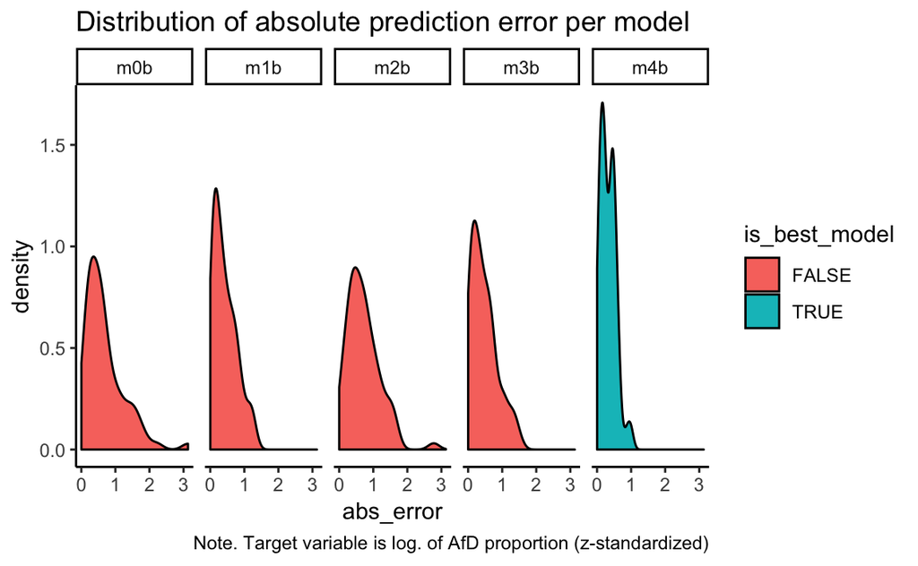

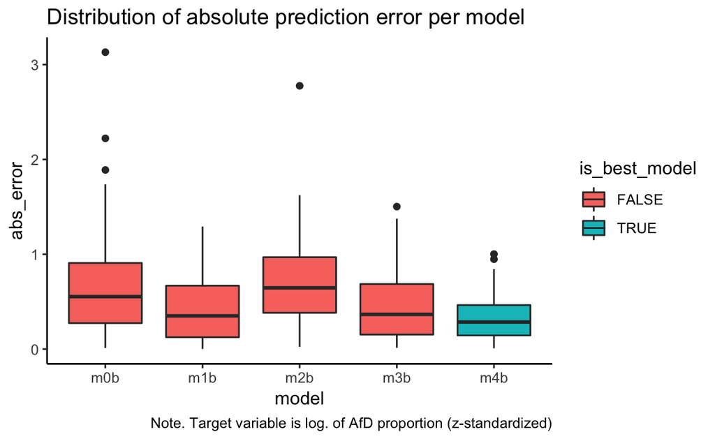

```r
model_error_long <- model_error %>%
  as_tibble() %>%
  gather(key = model, value = abs_error) %>%
  mutate(is_best_model = ifelse(model == best_model_name,
                                TRUE,
                                FALSE))

model_error_long %>%
  ggplot(aes(x = abs_error)) +
  facet_grid(. ~ model) +
  geom_density(aes(fill = is_best_model)) +
  theme_classic() +
  labs(title = "Distribution of absolute prediction error per model",
       caption = "Note. Target variable is log. of AfD proportion (z-standardized)")


model_error_long %>%
  ggplot(aes(x = model, y= abs_error)) +
  theme_classic() +
  geom_boxplot(aes(fill = is_best_model))  +
  labs(title = "Distribution of absolute prediction error per model",
       caption = "Note. Target variable is log. of AfD proportion (z-standardized)")
```

## Mean error of best model

Add the MEAN error of THE BEST MODEL to the data frame:

```r
d79 <- d79 %>%
  mutate(err_avg = model_error[[best_model_name]])
```

Let’s look at the distribution:

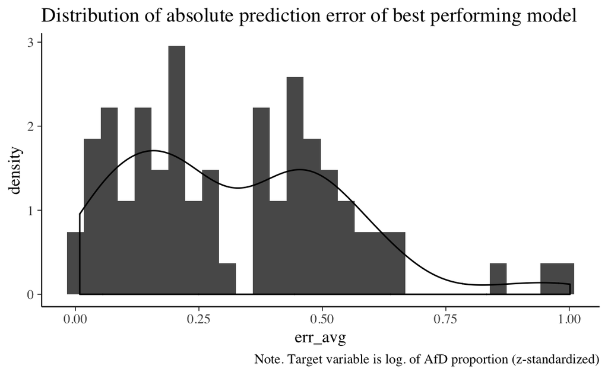

```r
d79 %>%
  ggplot(aes(x = err_avg, y = ..density..)) +
  geom_histogram() +
  geom_density()  +
  labs(title = "Distribution of absolute prediction error of best performing model",
       caption = "Note. Target variable is log. of AfD proportion (z-standardized)")
```

## Abolute error per model

Compute the median absolute error:

```r
md_abs_error_all_models <- map_dbl(model_error, median)
md_abs_error_all_models
```

[output not shown]

The median absolute errors show the averaged absolute error (as per median) of for each predicted case.

Compute the *mean* absolute error:

```r
mean_abs_error_all_models <- map_dbl(model_error, mean)
mean_abs_error_all_models
```

[output not shown]

Also, compute the IQR of the errors:

```r
modell_error_IQR <- lapply(models79, comp_abs_error, fun = IQR, data = d79)

md_of_model_iqr_error <- sapply(modell_error_IQR, median) %>% unlist()
```

# Average prediction

## Compute average prediction

```r
comp_avg_pred <- function(model, data, fun = mean) {

  posterior_per_person <- link(model)


  as_tibble(posterior_per_person) %>%
    summarise_all(fun) %>%
    gather() %>%
    rename(estimate = value) %>%
    pull(estimate) -> predictions_vec

  return(predictions_vec)
}
```

Apply the function on all models:

```r
model_avg_predictions <- lapply(models79, comp_avg_pred, data = d79)

names(model_avg_predictions) <- names(models79)
```

## Mean prediction of best model

```r
d79 <- d79 %>%
  mutate(pred_avg = model_avg_predictions[[best_model_name]])
```

## R squared of best model

Attention this is the uncorrected overfitting prone R squared. Note ther’s also no information about variability (ie, only point estimate).

```r
r2_bestmodel <- 1 - var(d79$err_avg) / var(d79$afd_prop_log_z)
r2_bestmodel
```

```
#> [1] 0.9383183
```

# Visualizing prediction error

Some preparation:

```r
model_error %>%
    as.data.frame() -> model_error_df


names(model_error_df) <- names(models79)

model_error_df %>%
  mutate(afd_prop_log_z = d79$afd_prop_log_z,
         id = 1:nrow(model_error_df)) -> model_error_df


modell_error_IQR %>%
  as.data.frame() -> model_error_IQR_df


names(model_error_IQR_df) <- names(models79)

model_error_IQR_df %>%
  mutate(id = 1:nrow(model_error_IQR_df)) -> model_error_IQR_df
```

Convert to long version for plotting:

```r
model_error_IQR_df %>%
  gather(key = model, value = iqr, -c(id)) %>%
  mutate(stat = "IQR") -> model_error_IQR_df_long


model_error_df %>%
  gather(key = model, value = error, -c(afd_prop_log_z, id)) %>%
  mutate(stat = "median") -> model_error_df_long

model_error_df_long %>%
  bind_rows(model_error_IQR_df_long) -> model_error_long


model_error_df_long %>%
  left_join(model_error_IQR_df_long, by = c("id", "model")) %>%
  select(-c(stat.x, stat.y)) -> model_error_md_iqr

glimpse(model_error_md_iqr)
```

```
#> Observations: 395
#> Variables: 5
#> $ afd_prop_log_z <dbl> -0.8711609, -1.2500260, -0.8608094, -0.7477890, -…
#> $ id             <int> 1, 2, 3, 4, 5, 6, 7, 8, 9, 10, 11, 12, 13, 14, 15…
#> $ model          <chr> "m0b", "m0b", "m0b", "m0b", "m0b", "m0b", "m0b", …
#> $ error          <dbl> 0.66834332, 1.04720833, 0.65799180, 0.54497141, 0…
#> $ iqr            <dbl> 1.0067613, 1.3856263, 0.9964098, 0.8833894, 0.642…
```

Now plot:

```r
as_tibble(md_abs_error_all_models) %>%
  mutate(model = model_names,
         best_model = ifelse(model_names == best_model_name, TRUE, FALSE)) -> md_abs_error_all_models

glimpse(md_abs_error_all_models)
```

```
#> Observations: 5
#> Variables: 3
#> $ value      <dbl> 0.5531430, 0.3502044, 0.6457614, 0.3662108, 0.2853005
#> $ model      <chr> "m0b", "m1b", "m2b", "m3b", "m4b"
#> $ best_model <lgl> FALSE, FALSE, FALSE, FALSE, TRUE
```

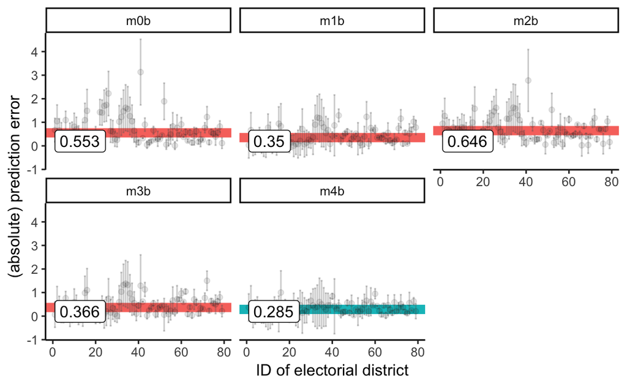

```r
p_model_error_md_iqr <- model_error_md_iqr %>%
  arrange(-error) %>%
  ggplot(aes(x = id)) +
  facet_wrap(~model) +
  geom_hline(aes(yintercept = value,
                 color = best_model),
             size = 3,
             data = md_abs_error_all_models
             ) +
  geom_errorbar(aes(ymin = error - (iqr/2),
                    ymax = error + (iqr/2)),
                alpha = .3,
                color = "gray40") +
  geom_point(aes(y = error), alpha = .1) +
  geom_label(aes(label = round(value, 3)), x = 1, y = .2,
            data = md_abs_error_all_models,
            hjust = 0) +
  guides(color=FALSE) +
  theme_classic() +
  labs(x = "ID of electorial district",
       y = "(absolute) prediction error")

p_model_error_md_iqr

ggsave(filename = "../img/model-error-comp.pdf")
```